# business_failure

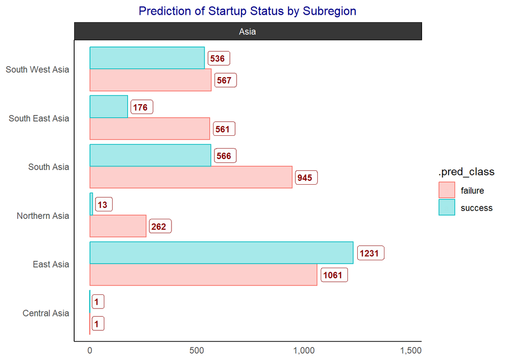

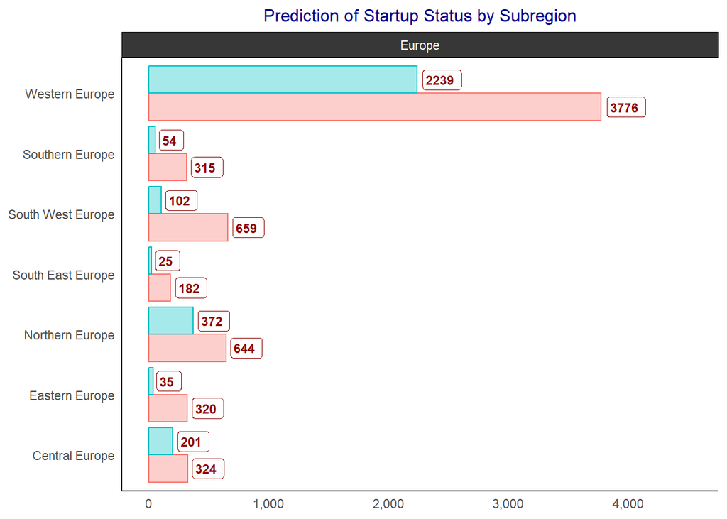

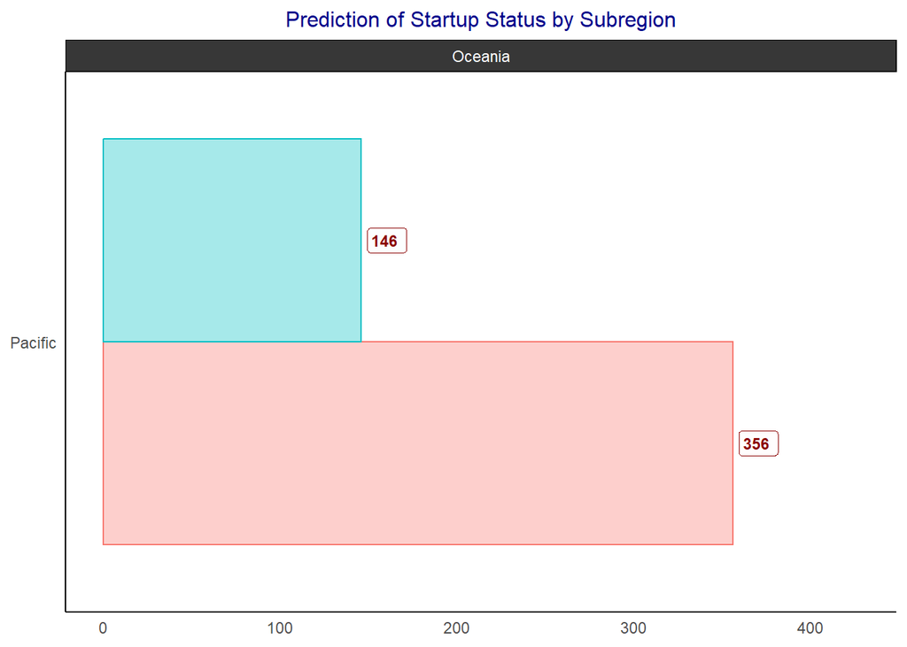

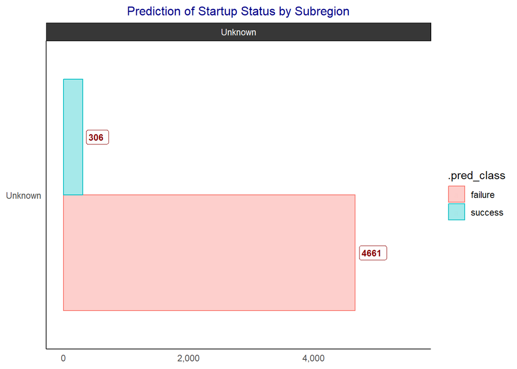

## Inconclusion

From a business standpoint, this analysis provides actionable insights for strategic decision-making. Companies seeking to establish a presence or launch new ventures can prioritize their efforts in regions with higher success probabilities, thereby increasing their chances of thriving in the competitive landscape. Additionally, investors and stakeholders may leverage this information to allocate resources more efficiently, focusing on regions with a proven track record of fostering successful startups.

However, it is essential to note that the success of a startup is influenced by a multitude of factors, including market conditions, customer preferences, competition, and management capabilities. Therefore, while our model offers valuable guidance, further investigation and domain expertise are crucial for comprehensive decision-making.